# SPRT Implementation

**前言**

# 前言:

(賴東昇,2017/5/25)

本報告根據 Wald (1945) Sequential Tests of Statistical Hypotheses，透過R語言來實做論文中的SPRT方法(Sequential probability ratio test)，並檢驗其檢定所需樣本數，與模擬所得之型一型二誤差。

- Github Page :https://github.com/hyades910739/mySPRT

**R-Implementation**

# R implementation

First, to make the codes more readable and maintainable, we use package “magrittr” here.

```r
library(magrittr)
```

### mySPRT

> mySPRT(data,H0,H1,alpha,beta,distribution=“bernoulli”,previous=NULL)

```r
#main function:
mySPRT = function(data,H0,H1,alpha,beta,distribution="bernoulli",previous=NULL){
  boundary = boundary.cal(alpha,beta,log=T);
####for llr
  if( class(previous)=="mySPRT"){
    if(previous$decision != "Continue Trials!") return(previous);
    if(previous$distribution != distribution) retrun("fause! Different distribution been applied.");
    prelogllr = previous$log.llr[length(previous$log.llr)];
    llh2 =  lh.f2.pre(data,H0,H1,boundary,distribution="bernoulli",pre.log.llr =prelogllr );
    llh2 = c(previous$log.llr,llh2);
  }else{
    llh2 =  lh.f2(data,H0,H1,boundary,distribution="bernoulli");
  }
  n2 = length(llh2);
####decisions:
  if(llh2[length(llh2)]>boundary$A) decision = "Reject H0!";
  if(llh2[length(llh2)]<boundary$B) decision = "Do not reject H0!";
  if(llh2[length(llh2)]<boundary$A & llh2[n2]>boundary$B ) decision = "Continue Trials!";

####prepare for result:
  res = list(
    decision = decision,
    llr = exp(llh2),
    log.llr = llh2,
    boundary.A = boundary$A,
    boundary.B = boundary$B,
    H0 = H0,
    H1 = H1,
    alpha = alpha,
    beta = beta,
    n=n2,
    distribution = distribution
  )
  class(res) = "mySPRT";
  return(res);
}


#return vector of liklihood ration
lh.f = function(data,H0,H1,distribution="bernoulli"){
  n = length(data)
  if(distribution =="bernoulli"){
    lhr = sapply(1:n,function(x){
      f1 = data[1:x] %>% dbinom(.,1,H1,log=T) %>% sum()
      f2 = data[1:x] %>% dbinom(.,1,H0,log=T) %>% sum()
      (f1-f2)
    })
    return(lhr)
  }
}

# calculate likelihood ratio:
lh.f2 = function(data,H0,H1,boundary,distribution="bernoulli"){
  n = length(data);
  f1 = c();
  f2 = c();
  lh = c();

  if(distribution =="bernoulli"){
    for(i in 1:n){
      f1[i] = data[1:i] %>% dbinom(. ,1,H1,log=T) %>% sum();
      f2[i] = data[1:i] %>% dbinom(. ,1,H0,log=T) %>% sum();
      lh[i] = f1[i]-f2[i];
      if(lh[i]>boundary$A){
        return (lh)
      }else if(lh[i]<boundary$B){
        return (lh)
      }
    }
    return(lh)
  }
}

# calculate likelihood ratio if previous exist:
lh.f2.pre = function(data,H0,H1,boundary,distribution="bernoulli",pre.log.llr){
  n = length(data);
  f1 = c();
  f2 = c();
  lh = c();

  if(distribution =="bernoulli"){
    for(i in 1:n){
      f1[i] = data[1:i] %>% dbinom(. ,1,H1,log=T) %>% sum();
      f2[i] = data[1:i] %>% dbinom(. ,1,H0,log=T) %>% sum();
      lh[i] = f1[i]-f2[i]+pre.log.llr;
      if(lh[i]>boundary$A){
        return (lh)
      }else if(lh[i]<boundary$B){
        return (lh)
      }
    }
  }
}

# return list of boundary.A boundary.B
boundary.cal = function(alpha,beta,log=T){
  A = (1-beta)/alpha;
  B = beta/(1-alpha);
  if(log){
    A = log(A);
    B = log(B);
  }
  boundary = list(A=A,B=B);
  return(boundary)
}
```

#### useage:

- data : dataset, vector.
- H0 : H0 hypothesis, numeric.
- H1 : H1 Hypothesis, numeric.
- alpha : given alpha for the test, numeric.
- beta : given beta for the test, numeric.
- distribution : specify which distribution,bernoulli only now.
- previous : you can pass previous test here(decision: continue trial), class“mySPRT”

#### return:

mySPRT function return a class “mySPRT” list, which contain following:

- decision
- llr : liklihood ratio
- log.llr : log liklihood ratio
- boundary.A
- boundary.B
- H0
- H1
- alpha
- beta
- n : sample size(when test stop at)
- distribution

### s3 methods:

> plot(mySPRT)

```r
plot.mySPRT = function(sprt){
  A = sprt$boundary.A %>% exp()
  B = sprt$boundary.B %>% exp()
  A.text = paste("boundary.A: ",A,sep="")
  B.text = paste("boundary.B: ",round(B,4),sep="")

  plot(1:sprt$n,sprt$llr,pch=19,lwd=3,xlab = "Trials",ylab="Likelihood-Ratio",
       ylim = c(min(B,sprt$llr),max(A,sprt$llr)))
  abline(A,0,lwd=1,lty=2,col="red")
  abline(B,0,lwd=1,lty=2,col="blue")
  par(xpd=TRUE)
  legend(x=(sprt$n/4),y=max(A,sprt$llr)*1.2,c(A.text,B.text),lty=2,col=c("red","blue"))
  par(xpd=F)
}
```

This function plot the test procedure, boundary, and llr at each sample.

> print(mySPRT)

```r
print.mySPRT = function(sprt){
 cat("#SPRT test:\n",
     "decision:",sprt$decision,"\n\n",
     "---\n",
     "distribution = ",sprt$distribution,"\n",
     "n = ",sprt$n,"\n",
     "boundary.A = ",sprt$boundary.A,"\n",
     "boundary.B = ",sprt$boundary.B,"\n",
     "alpha = ",sprt$alpha,"\n",
     "beta = ",sprt$beta,"\n")
}
```

This function print out the test report.

**Examples**

# Examples:

#### EX1:

We produce a set of samples from Bernoulli(p=0.8), and test H0: p=0.5, H1: p=0.8.

```r
set.seed(689)
test2 = replicate(20,rbinom(1,1,0.8))
sprt2 = mySPRT(test2,0.5,0.8,0.05,0.2)
print(sprt2)
```

```
## #SPRT test:
##  decision: Reject H0!
##
##  ---
##  distribution =  bernoulli
##  n =  9
##  boundary.A =  2.772589
##  boundary.B =  -1.558145
##  alpha =  0.05
##  beta =  0.2
```

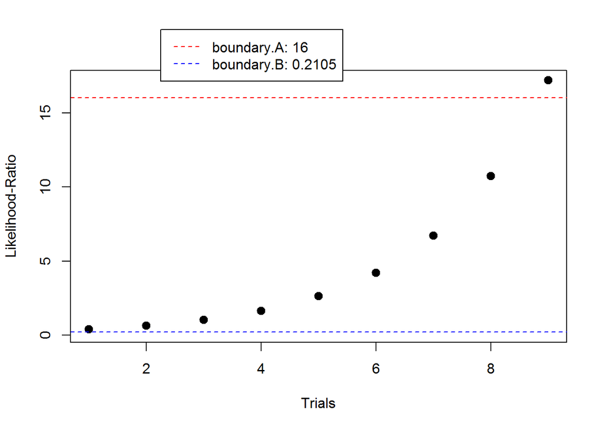

```r
plot(sprt2)
```

#### EX2:

```r
set.seed(689)
test3 = replicate(20,rbinom(1,1,0.5))
sprt3 = mySPRT(test3,0.35,0.55,0.05,0.1)
print(sprt3)
```

```
## #SPRT test:
##  decision: Continue Trials!
##
##  ---
##  distribution =  bernoulli
##  n =  20
##  boundary.A =  2.890372
##  boundary.B =  -2.251292
##  alpha =  0.05
##  beta =  0.1
```

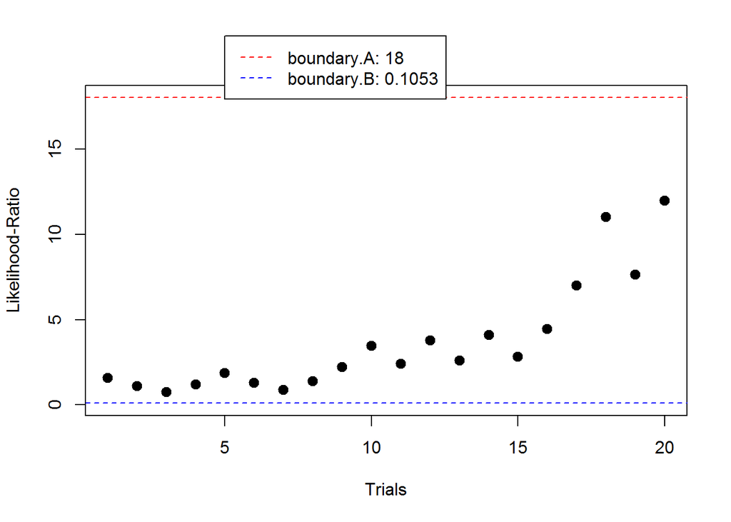

```r
plot(sprt3)
```

This time, none of the sample drop out of AB boundary. We get the decision, “Counitue trials!”

**Verification**

# verification:

Next, we would like to know the following:  
1.The type I and type II error rate based on our implementation. Does it match up alpha and beta we set before the test?

2.To get decision(reject or do not reject), how many sample we need?

#### Q1:

To simplify the procedure,we wrote a short function to conduct the test.It returns the rate of decision “reject”" and “do not reject”.

```r
testSPRT = function(repeatT,n,actual,h0,h1,alpha,beta){
  test = replicate(repeatT,replicate(n,rbinom(1,1,actual)))

  apply(test,2,FUN=function(x){
    mySPRT(data=x,H0=h0,H1=h1,alpha=alpha,beta=beta)$decision
  }) %>% table() %>% '/'(repeatT)
}
```

Then, we produce samples from Ber(p=0.5) and check the type I error rate:  
repeat=100 :

```r
set.seed(689)
testSPRT(100,1000,0.5,0.5,0.8,0.05,0.1)
```

```
## .
## Do not reject H0!        Reject H0!
##              0.98              0.02
```

repeat = 1000 :

```r
testSPRT(1000,1000,0.5,0.5,0.8,0.05,0.1)
```

```
## .
## Do not reject H0!        Reject H0!
##             0.959             0.041
```

This time, set Ber(p=0.8) and check the type II error rate:  
repeat = 100 :

```r
testSPRT(100,1000,0.8,0.5,0.8,0.05,0.1)
```

```
## .
## Do not reject H0!        Reject H0!
##              0.09              0.91
```

repeat = 1000 :

```r
testSPRT(1000,1000,0.8,0.5,0.8,0.05,0.1)
```

```
## .
## Do not reject H0!        Reject H0!
##             0.072             0.928
```

#### Q2:

For Q2, similarly, we wrote another function, it produce five number of sample size n and the Boxplot:

```r
testSPRT2 = function(repeatT,n,actual,h0,h1,alpha,beta){
  test = replicate(repeatT,replicate(n,rbinom(1,1,actual)))
  header = paste("sample size \nalpha=",alpha,",beta=",beta,",repat=",repeatT,sep="")

  apply(test,2,FUN=function(x){
    mySPRT(data=x,H0=h0,H1=h1,alpha=alpha,beta=beta)$n
  })  %T>% boxplot(.,main=header) %>% summary()
}
```

Then run the test with different alpha,beta,H1:

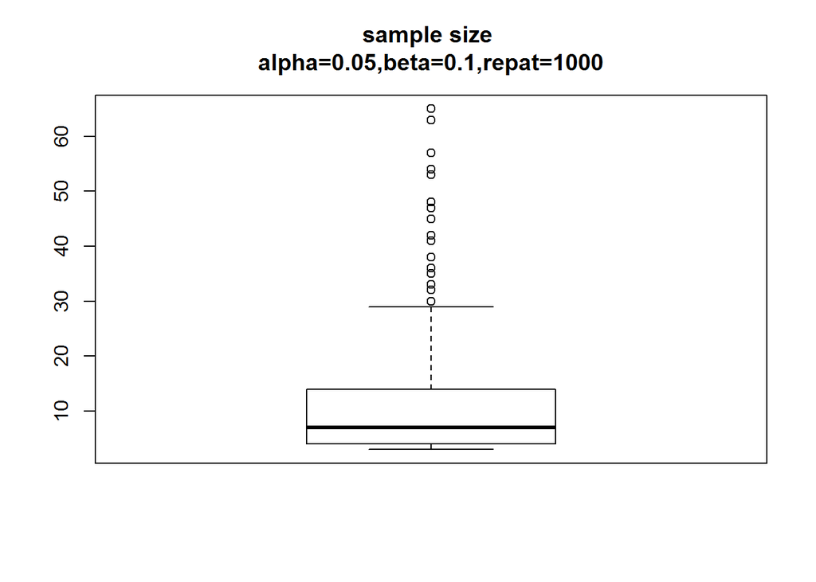

```
##    Min. 1st Qu.  Median    Mean 3rd Qu.    Max.
##    3.00    4.00    7.00   10.38   14.00   65.00
```

```r
testSPRT2(1000,1000,0.5,0.5,0.8,0.05,0.1)
```

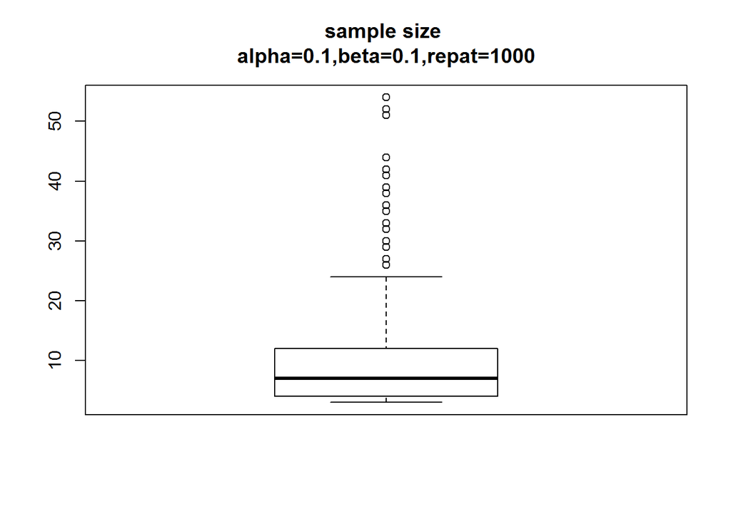

```
##    Min. 1st Qu.  Median    Mean 3rd Qu.    Max.
##   3.000   4.000   7.000   9.514  12.000  54.000
```

```r
testSPRT2(1000,1000,0.5,0.5,0.8,0.1,0.1)
```

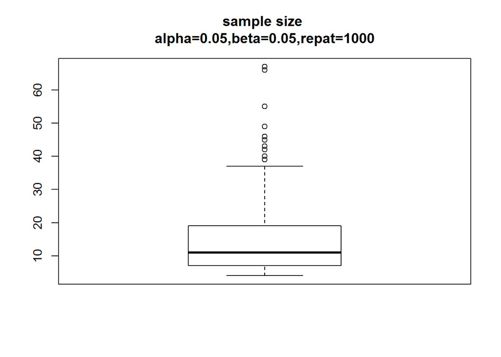

```
##    Min. 1st Qu.  Median    Mean 3rd Qu.    Max.
##    4.00    7.00   11.00   13.98   19.00   67.00
```

```r
testSPRT2(1000,1000,0.5,0.5,0.8,0.05,0.05)
```

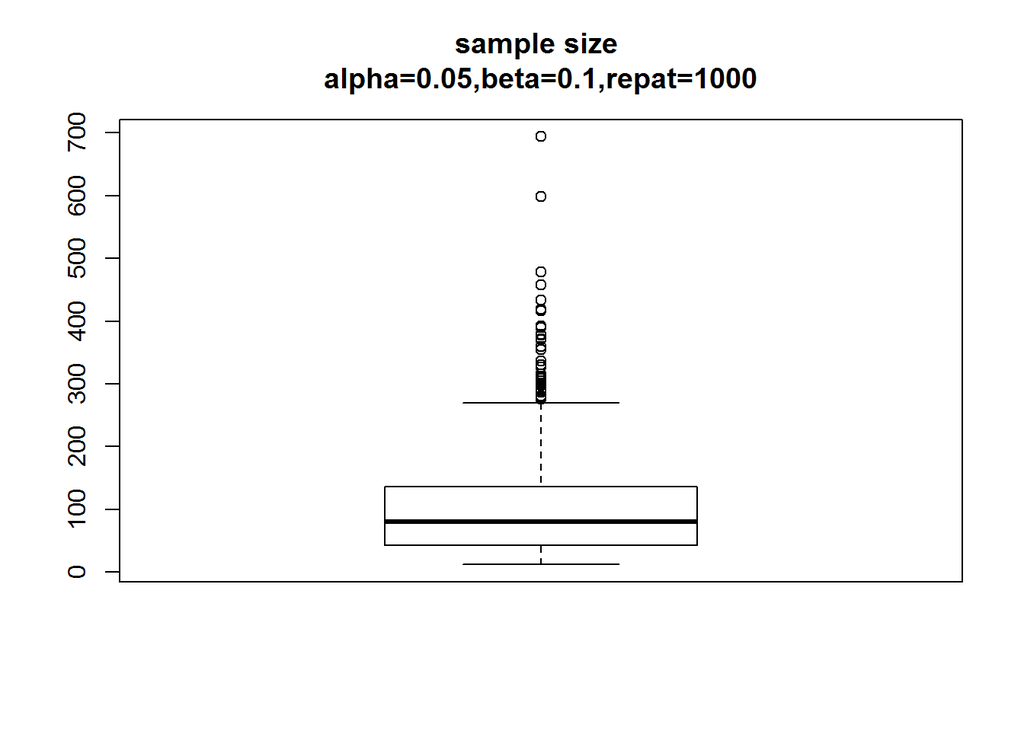

```
##    Min. 1st Qu.  Median    Mean 3rd Qu.    Max.
##    12.0    43.0    80.0   102.2   136.0   694.0
```

```r
testSPRT2(1000,1000,0.5,0.5,0.6,0.05,0.1)
```

We could see that, in most case, the sample size is fairly small. On the other hand, sample size increases when we lower alpha, beta, or the difference between H0 and H1.